# DataExploration_Practical

2022-08-02

# **The Set-up**

## *Learning objectives.*

1. Load tables into `R` and explore their content.
2. Execute basic looping routines using the `*apply()` and `for()` functions.
3. Graphically explore the variability in the variables in a data set based.
4. Graphically compare the variables values between categorical groups
5. Establish the normality of a variable and evaluate different transformations to achieve normality.
6. Determine the correlation between two random variables and the significance of such correlation.

## *Before you start*

The practical will be run using *RStudio cloud* to avoid individual machine troubleshooting. This means you **need** to have an account for *RStudio cloud*.

However, remember to have [`R`](https://cran.r-project.org) and [R-studio](http://www.rstudio.com/) in your/room computer so you can work on the project after class.

**You should have also** 1. Read chapter 2 of Borcard et al. Numerical ecology with R. Springer, 2018. 2. Done the Tutorial for this week.

## *The way it’s going to be run*

In this 3h practical you will to implement what you have learned in the class about Exploratory Data Analysis in `R`.

You will be building and **R-Markdown** document during the class. **R-Markdown** documents allows you to combine your code, its results, and your prose commentary into a single document. If you manage to produce a document your code works. The resulting file (a html) is what you will hand-in at the end of the practical.

This 3h practical is divided into two parts. **DO NOT COPY AND PASTE THE CODE!**

Also try to write your own `R`-code and run it **DO NOT COPY THE CODE OF SOMEONE ELSE**. Writing your code and figuring out why it does not work is the best way to understand the dynamics of the `R` language and the tasks you are doing. Also, you have an excellent teaching assistant resource - ask him and/or me all the questions you have.

The final document will have for classes of boxes

**The text in the blue filled box marked as **Your task** states what you need to do**

```r
#
# The code in the window marked like this shows where you need to write your code
#
```

**The text in the green filled box marked as **Question** phrases a question.**

**Here you will place the answer to the **question**.**

# **Exploring Denmark’s biodiversity and environmental data.**

##*1. Load the Data*

**Your task:**

Load the data in *Biowide_With_EnvDta.csv*, located in the Web URL https://raw.githubusercontent.com/AlejoOrdonez/StaGeoMod2022/main/Week%201%20-%20Data%20Exploration/Practical/Data/Biowide_With_EnvDta.csv. For this:

- Define an object named URL.Loc with the string of the Web URL.
- Use `read.csv` to load the file - The file is comma-separated
- Save the object as `DK.Biodiv`.

```r
# Define an object named URL.Loc with the string of the Web URL.

URL.Loc <- "https://raw.githubusercontent.com/AlejoOrdonez/StaGeoMod2022/main/Week%201%20-%20Data%20Exploration/Practical/Data/Biowide_With_EnvDta.csv"

# Read the file and save it as an object named `DK.Biodiv`
DK.Biodiv <-  read.csv(URL.Loc)

#
```

##*2. What is in the Table?*

**Your task:**

Based on the data stored in the object `DK.Biodiv`, write code to answer the flowing questions:

- What is the object class of `DK.Biodiv` data set?

```r
# What is the object class of `DK.Biodiv` data set?
class(DK.Biodiv)
```

```
## [1] "data.frame"
```

```r
#
```

**Your task:**

Based on the data stored in the object `DK.Biodiv`, write code to answer the flowing questions:

- Which are the variable names in the `DK.Biodiv` data set?

```r
#Which are the variable names in the `DK.Biodiv` data set?
names(DK.Biodiv)
```

```
##  [1] "X"                "ID"               "decimalLongitude" "decimalLatitude"
##  [5] "S.AllGrp"         "S.Arthropoda"     "S.Spermatophyte"  "S.Magnoliophyta"
##  [9] "landsdele"        "Geology"          "NatDensBasMp"     "OpnNatBasMp"
## [13] "ForDenBasMp"      "AgrBasMp"         "WetLndBasMp"      "Dis2Cost"
## [17] "HII"              "Slope30mAgg"      "ElevHet"          "SoilTypHet"
## [21] "SoilpH"           "NDVI"             "MAT"              "TempSeas"
## [25] "AnnPrec"          "PrecSea"          "PET"
```

```r
#
```

**Your task:**

Based on the data stored in the object `DK.Biodiv`, write code to answer the flowing questions:

- How many observations are in the `DK.Biodiv` data set?

```r
#How many observations are in  the `DK.Biodiv` data set?
dim(DK.Biodiv)[1]
```

```
## [1] 130
```

```r
#
```

**Your task:**

Based on the data stored in the object `DK.Biodiv`, write code to answer the flowing questions:

- How many variables are in the `DK.Biodiv` data set?

```r
#How many variables are in  the `DK.Biodiv` data set?
dim(DK.Biodiv)[2]
```

```
## [1] 27
```

```r
#or
length(names(DK.Biodiv))
```

```
## [1] 27
```

```r
#
```

**Your task:**

Based on the data stored in the object `DK.Biodiv`, write code to answer the flowing questions:

- List the variables that are `numeric`, and `character`.

```r
#List the variables that are `numeric` and `character`.

# Numeric variables
NumVar <- names(DK.Biodiv)[(sapply(DK.Biodiv,class)%in%c("numeric","integer"))]
NumVar
```

```
##  [1] "X"                "ID"               "decimalLongitude" "decimalLatitude"
##  [5] "S.AllGrp"         "S.Arthropoda"     "S.Spermatophyte"  "S.Magnoliophyta"
##  [9] "NatDensBasMp"     "OpnNatBasMp"      "ForDenBasMp"      "AgrBasMp"
## [13] "WetLndBasMp"      "Dis2Cost"         "HII"              "Slope30mAgg"
## [17] "ElevHet"          "SoilTypHet"       "SoilpH"           "NDVI"
## [21] "MAT"              "TempSeas"         "AnnPrec"          "PrecSea"
## [25] "PET"
```

```r
# Character variables
CharVar <- names(DK.Biodiv)[(sapply(DK.Biodiv,class)%in%c("character"))]
CharVar
```

```
## [1] "landsdele" "Geology"
```

**Question:** What is the Difference between `numeric` and `integer` objects?

**Numeric** data consists of numbers with decimals points. **Integer** data consists of whole numbers. Operational they are the same, but in `R` **integers** are subsets of **numeric**.

##*3. Summary statistics*

**Your task:**

Based on the data stored in the object `DK.Biodiv`, you will estimate.

- The mean of all `numerical` variables. You **MUST** use an `apply()` function in this task.

```r
# mean of all `numerical` variables.
Mean.DK.Biodiv <- apply(X = DK.Biodiv[,NumVar], # Data frame with the Data
                        MARGIN = 2, # Dimension on which the function will be applied over
                        FUN = mean, # Function to be applied over
                        na.rm = T # Do not consider NA values
                        )
Mean.DK.Biodiv
```

```
##                X               ID decimalLongitude  decimalLatitude
##     6.550000e+01     6.550000e+01     1.026381e+01     5.591567e+01
##         S.AllGrp     S.Arthropoda  S.Spermatophyte  S.Magnoliophyta
##     2.794077e+02     1.301231e+02     4.135385e+01     4.050769e+01
##     NatDensBasMp      OpnNatBasMp      ForDenBasMp         AgrBasMp
##     7.495214e-01     3.423912e-01     4.071302e-01     1.708814e-01
##      WetLndBasMp         Dis2Cost              HII      Slope30mAgg
##     7.081353e-02     8.398433e+03     2.601883e+01     3.354969e+00
##          ElevHet       SoilTypHet           SoilpH             NDVI
##     6.580364e+00     2.507812e+00     5.563303e+01     6.016260e-01
##              MAT         TempSeas          AnnPrec          PrecSea
##     8.452460e+00     5.731855e+02     6.966522e+02     2.229007e+01
##              PET
##     4.369848e+02
```

```r
#
```

**Your task:**

Based on the data stored in the object `DK.Biodiv`, you will estimate.

- The standard deviation of all `numerical` variables. You **MUST** use a `sapply()` or `lapply()` function in this task.

```r
# The standard deviation of all `numerical` variables.
SD.DK.Biodiv <- sapply(X = NumVar, # a vector defining the looping space
                       function(x){ # Function to be applied over
                         sd(x = DK.Biodiv[,x], # a numeric vector
                            na.rm = T # Do not consider NA values
                            )
                         })

SD.DK.Biodiv
```

```
##                X               ID decimalLongitude  decimalLatitude
##     3.767183e+01     3.767183e+01     1.346369e+00     7.865777e-01
##         S.AllGrp     S.Arthropoda  S.Spermatophyte  S.Magnoliophyta
##     8.079860e+01     3.229923e+01     2.485208e+01     2.507083e+01
##     NatDensBasMp      OpnNatBasMp      ForDenBasMp         AgrBasMp
##     2.436655e-01     2.933185e-01     3.038665e-01     2.210266e-01
##      WetLndBasMp         Dis2Cost              HII      Slope30mAgg
##     9.963629e-02     9.796777e+03     8.295831e+00     1.948761e+00
##          ElevHet       SoilTypHet           SoilpH             NDVI
##     5.120699e+00     1.064799e+00     4.881296e+00     8.483489e-02
##              MAT         TempSeas          AnnPrec          PrecSea
##     2.711387e-01     2.398347e+01     1.003998e+02     3.850041e+00
##              PET
##     5.410123e+01
```

```r
#
```

**Your task:**

Based on the data stored in the object `DK.Biodiv`, you will estimate.

- The [coefficient of variation](https://en.wikipedia.org/wiki/Coefficient_of_variation) for all `numerical` variables.

```r
# The coefficient of variation for all `numerical` variables.
CV.DK.Biodiv <- Mean.DK.Biodiv/SD.DK.Biodiv
CV.DK.Biodiv
```

```
##                X               ID decimalLongitude  decimalLatitude
##        1.7386998        1.7386998        7.6233212       71.0872775
##         S.AllGrp     S.Arthropoda  S.Spermatophyte  S.Magnoliophyta
##        3.4580759        4.0286737        1.6639996        1.6157301
##     NatDensBasMp      OpnNatBasMp      ForDenBasMp         AgrBasMp
##        3.0760262        1.1673016        1.3398324        0.7731257
##      WetLndBasMp         Dis2Cost              HII      Slope30mAgg
##        0.7107202        0.8572649        3.1363743        1.7215904
##          ElevHet       SoilTypHet           SoilpH             NDVI
##        1.2850519        2.3551982       11.3971846        7.0917285
##              MAT         TempSeas          AnnPrec          PrecSea
##       31.1739309       23.8991929        6.9387808        5.7895679
##              PET
##        8.0771680
```

```r
# OR
CV.DK.Biodiv <- apply(X = DK.Biodiv[,NumVar], # Data frame with the Data
                        MARGIN = 2, # Dimension on which the function will be applied over
                        FUN = function(x){mean(x,na.rm = T)/sd(x,na.rm = T)} # Function to be applied over
                        )
CV.DK.Biodiv
```

```
##                X               ID decimalLongitude  decimalLatitude
##        1.7386998        1.7386998        7.6233212       71.0872775
##         S.AllGrp     S.Arthropoda  S.Spermatophyte  S.Magnoliophyta
##        3.4580759        4.0286737        1.6639996        1.6157301
##     NatDensBasMp      OpnNatBasMp      ForDenBasMp         AgrBasMp
##        3.0760262        1.1673016        1.3398324        0.7731257
##      WetLndBasMp         Dis2Cost              HII      Slope30mAgg
##        0.7107202        0.8572649        3.1363743        1.7215904
##          ElevHet       SoilTypHet           SoilpH             NDVI
##        1.2850519        2.3551982       11.3971846        7.0917285
##              MAT         TempSeas          AnnPrec          PrecSea
##       31.1739309       23.8991929        6.9387808        5.7895679
##              PET
##        8.0771680
```

```r
#
```

**Question:** Can you compare the coefficient of variations of different variables? is yes/no, explain why?

**Your task:**

Based on the data stored in the object `DK.Biodiv`, you will estimate.

- The mean of all `numerical` variables per region. You **MUST** use a combination of `apply()` and `tapply()` function in this task.

```r
# The mean of all `numerical` variables per region.
RegMean.DK.Biodiv <-  apply(X = DK.Biodiv[,NumVar], # Data frame with the Data
                        MARGIN = 2, # Dimension on which the function will be applied over
                        FUN = function(x){# Function to be applied over
                          tapply(X = x, # vector to aggregate
                                 INDEX = DK.Biodiv$landsdele, # The grouping factor
                                 FUN = mean, # Function to be applied over
                                 na.rm = T # Do not consider NA values
                                 )
                        })
RegMean.DK.Biodiv
```

```
##                    X       ID decimalLongitude decimalLatitude S.AllGrp
## Hovedstaden 57.00000 57.00000        12.173547        56.00054 287.6667
## Midtjylland 78.93939 78.93939         9.482998        56.09813 274.2121
## Nordjylland 72.92308 72.92308         9.619064        57.18763 253.9615
## Sjælland    46.31429 46.31429        11.769809        55.22320 306.0286
## Syddanmark  69.62963 69.62963         9.250182        55.33715 273.0000
##             S.Arthropoda S.Spermatophyte S.Magnoliophyta NatDensBasMp
## Hovedstaden     117.7778        32.11111        31.22222    0.8868857
## Midtjylland     134.0606        42.57576        41.42424    0.7769475
## Nordjylland     115.0000        36.11538        34.84615    0.8395823
## Sjælland        139.4857        51.14286        50.82857    0.6846694
## Syddanmark      131.8519        35.29630        34.55556    0.6675544
##             OpnNatBasMp ForDenBasMp   AgrBasMp WetLndBasMp  Dis2Cost      HII
## Hovedstaden   0.3753275   0.5115583 0.05471074  0.11698785  8643.746 30.25293
## Midtjylland   0.3741024   0.4028450 0.14010284  0.05816212 12497.156 27.47831
## Nordjylland   0.3911925   0.4483898 0.11253283  0.05207372  5988.434 21.95543
## Sjælland      0.3413243   0.3433451 0.23488687  0.06128056  6417.661 23.30435
## Syddanmark    0.2470434   0.4205110 0.22044048  0.10128820  8499.127 29.96190
##             Slope30mAgg  ElevHet SoilTypHet   SoilpH      NDVI      MAT
## Hovedstaden    2.734665 4.568147   2.777778 56.87500 0.6103682 8.250029
## Midtjylland    4.040819 7.773029   2.225806 54.25000 0.5963194 8.313656
## Nordjylland    3.259320 7.293377   2.038462 53.90476 0.6065179 8.359648
## Sjælland       3.509643 6.617739   3.057143 59.07143 0.5932606 8.524883
## Syddanmark     2.632263 5.062500   2.481481 54.33333 0.6098783 8.659344
##             TempSeas  AnnPrec  PrecSea      PET
## Hovedstaden 606.4800 640.1195 22.70574 449.3637
## Midtjylland 563.3007 750.3487 23.04776 478.9509
## Nordjylland 563.2279 714.4106 23.71283 415.9937
## Sjælland    592.7915 593.3785 19.41020 389.8324
## Syddanmark  556.1377 774.5796 23.83084 465.2341
```

##*3. Graphical representations*

**Your task:**

Based on the data stored in the object `DK.Biodiv`, you will write code to plot:

- A bar-plot that summarises the mean *Nature density* (`NatDensBasMp`) across observations in each region (`landsdele`).

*Add to this bar plot the [95% CI error bars](https://en.wikipedia.org/wiki/Confidence_interval) using the function `arrows()`.

- You **MUST** use a `tapply()` function to generate the necessary summaries (i.e., Means, SD, and Number of observations).

```r
#A bar-plot that summarises the mean *Nature density* (`NatDensBasMp`) across observations in each region (`landsdele`).
# Add to this bar plot the 95% CI error bars using the function `arrows()`

## Estimate the mean Nature density per region
NatDen.Mean <- tapply(X = DK.Biodiv$NatDensBasMp, # Data frame with the Data
                      INDEX = DK.Biodiv$landsdele, # The grouping factor
                      FUN = mean, # Function to be applied over
                      na.rm = T # Do not consider NA values
                      )
NatDen.Mean
```

```
## Hovedstaden Midtjylland Nordjylland    Sjælland  Syddanmark
##   0.8868857   0.7769475   0.8395823   0.6846694   0.6675544
```

```r
## Estimate the Nature density sd per region
NatDen.SD <- tapply(X = DK.Biodiv$NatDensBasMp, # Data frame with the Data
                      INDEX = DK.Biodiv$landsdele, # The grouping factor
                      FUN = sd, # Function to be applied over
                      na.rm = T # Do not consider NA values
                      )
NatDen.SD
```

```
## Hovedstaden Midtjylland Nordjylland    Sjælland  Syddanmark
##   0.1109956   0.2244997   0.2027811   0.2871322   0.2305906
```

```r
## Estimate the number of observation  per region
NatDen.n <- table(DK.Biodiv$landsdele)
NatDen.n
```

```
##
## Hovedstaden Midtjylland Nordjylland    Sjælland  Syddanmark
##           9          33          26          35          27
```

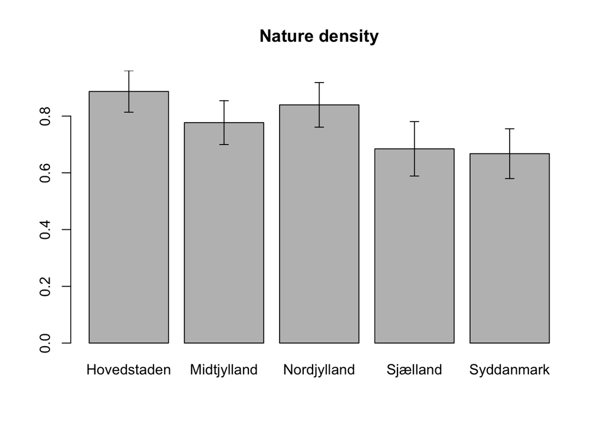

```r
## Determine the Low an high value of the 95% CI
LowCI <- NatDen.Mean - qnorm(0.976)*(NatDen.SD/sqrt(NatDen.n))
HighCI <- NatDen.Mean + qnorm(0.976)*(NatDen.SD/sqrt(NatDen.n))

## Plot the barplot
BarsNat <- barplot(height = NatDen.Mean, # Variable to plot
                   main = "Nature density", # Add the variable name as title
                   ylim = c(0,max(HighCI)) # Determine the range of the y-axis
                   )

## Plot the Arrows with the 96%CI
arrows(x0 = BarsNat, #coordinates of points from which to draw
       y0 = LowCI, #coordinates of points from which to draw
       y1 = HighCI, #coordinates of points from which to draw
       angle = 90, # angle of the arrow (90 is flat)
       length = 0.05, # length of the edges of the arrow head
       code = 3, # Arrowhead in on or both ends
       )
```

```r
#
```

**Question:** DO you see differences in *Nature density* of the sampled sites between regions? Explain why yes/no.

Yes, there are differences between **GROUP** of regions. On group is composed by Hovedstaden, Midtjylland, and Nordjylland; and a higher Nature density. The second group is composed by Sjælland and Syddanmark, and has comparative lower Nature density.

**Your task:**

Based on the data stored in the object `DK.Biodiv`, you will write code to plot:

- A bar-plot that summarises the mean and error bars of *Human Impact* (`HII`) per [quantile](https://en.wikipedia.org/wiki/Quantile) of *total species richness* (`S.AllGrp`).
- You **MUST** use the `quantile()` and `findInterval()` functions to determine tow wich *total species richness* quantile each observation belongs.
- You **MUST** use a `tapply()` function to generate the necessary summaries (i.e., Means, SD, and Number of observations).

```r
# A bar-plot that summarises the mean and error bars of *Human Impact* (`HII`) per quantile of species richness (`S.AllGrp`).

## Estimate the quantiles for S.AllGrp
RichQuant <- quantile(x = DK.Biodiv$S.AllGrp, # Vector to quantify
                      na.rm = T # Do not consider NA values
                      )

# Determine to which quantile each observation belongs
RichQuantSumm <- findInterval(x = DK.Biodiv$S.AllGrp, # Vector to classify
                              vec = RichQuant, # A vector with the intervals
                              rightmost.closed = T, # Determine if the max value correspond to clas N or N-1
                              )

## Estimate the mean Human Impact per quantile
HII.Mean <- tapply(X = DK.Biodiv$HII, # Data frame with the Data
                   INDEX = RichQuantSumm, # The grouping factor
                   FUN = mean, # Function to be applied over
                   na.rm = T # Do not consider NA values
                   )
HII.Mean
```

```
##        1        2        3        4
## 27.15272 23.51609 25.56877 27.71676
```

```r
## Estimate Human Impact sd per quantile
HII.SD <- tapply(X = DK.Biodiv$HII, # Data frame with the Data
                      INDEX = RichQuantSumm, # The grouping factor
                      FUN = sd, # Function to be applied over
                      na.rm = T # Do not consider NA values
                      )
HII.SD
```

```
##        1        2        3        4
## 8.699580 7.425603 7.890419 8.812978
```

```r
## Estimate the number of observation  per quantile
HII.n <- table(RichQuantSumm)
HII.n
```

```
## RichQuantSumm
##  1  2  3  4
## 33 31 33 33
```

[figure not shown]

```r
## Determine the Low an high value of the 95% CI
LowCI <- HII.Mean - qnorm(0.976)*(HII.SD/sqrt(HII.n))
HighCI <- HII.Mean + qnorm(0.976)*(HII.SD/sqrt(HII.n))

## Plot the barplot
BarsHII <- barplot(height = HII.Mean, # Variable to plot
                   main = "Nature density", # Add the variable name as title
                   ylim = c(0,max(HighCI)), # Determine the range of the y-axis
                   names.arg = paste(1:4,"- quantile") # Names under each bar
                     )

## Plot the Arrows with the 96%CI
arrows(x0 = BarsHII, #coordinates of points from which to draw
       y0 = LowCI, #coordinates of points from which to draw
       y1 = HighCI, #coordinates of points from which to draw
       angle = 90, # angle of the arrow (90 is flat)
       length = 0.05, # length of the edges of the arrow head
       code = 3, # Arrowhead in on or both ends
       )
```

```r
#
```

**Question:** Do you see differences in *human Impact* between quantiles of species richness? What is the implication of the existence or not of diferecnes?

There are not differences in *human impact* between quantiles of species richness. This pattern indicates no relation between *human impact* and changes in species richness.

**Your task:**

Based on the data stored in the object `DK.Biodiv`, you will write code to plot:

- A box-plot that summarises the variation in *Slopes* (`Slope30mAgg`) across observations in each region (`landsdele`). In this figure you will colour code each box-plot using a [hcl diverging pallets](https://blog.r-project.org/2019/04/01/hcl-based-color-palettes-in-grdevices/index.html).

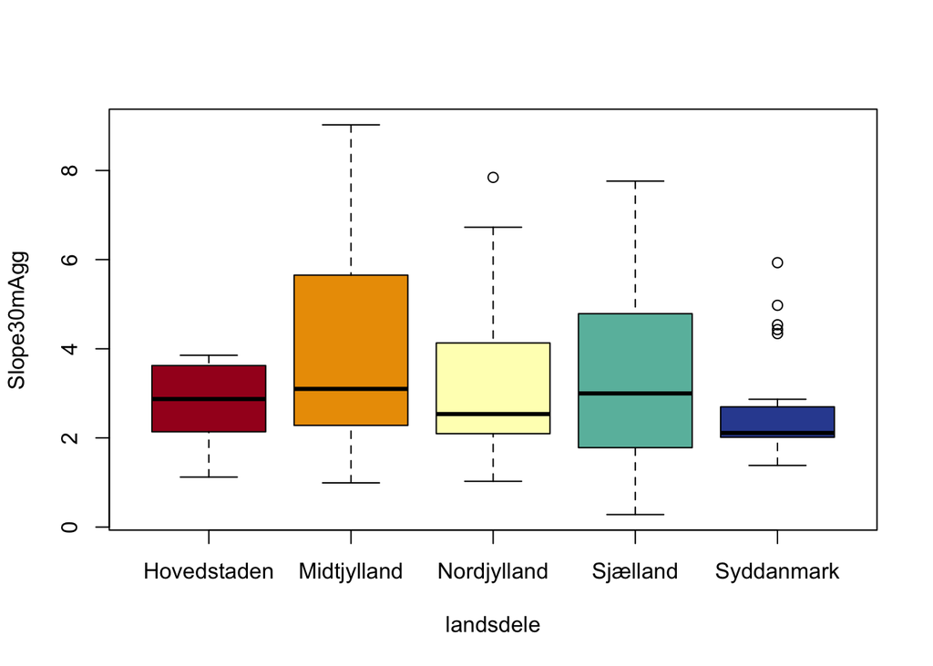

```r
# A box-plot that summarises the variation in *Slopes* (`Slope30mAgg`) across observations in each region (`landsdele`).
# colour code each box-plot using a hcl diverging pallet.


## Set the colour per Region
ClPerReg <- hcl.colors(n = length(unique(DK.Biodiv$landsdele)),# the number of colours
                       palette = 'RdYlBu' # palette name, Here a red to yellow to blue
                       )
## Draw the Boxplot

boxplot(Slope30mAgg ~ landsdele, # formula defining the variable to summarize and the grouping
        data = DK.Biodiv, # the Data frame with the Data
        col = ClPerReg # Thw color of each box.plot
        )
```

**Question:** What is the box plot of *SLopes* per region show?

##*4. Normality tests*

For the rest of the practical you will use a subset of the data stored in the object `DK.Biodiv`. The subset will include the flowing variables:

1. *Richness of all sampled species* [`S.AllGrp`]
2. *Region* [`landsdele`]
3. *Parental material* [`Geology`]
4. *Nature Density* [`NatDensBasMp`]
5. *Distance to coast* [`Dis2Cost`]
6. *Human Impact Index* [`HII`]
7. *Slope* [`Slope30mAgg`]
8. *Precipitation Seasonality* [`PrecSea`]

**Your task:**

Based on the data stored in the `DK.Biodiv` object, you will write code to subset the main data object into a `data.frame` named `DK.Biodiv.Smpl` that **ONLY** includes the eigth key variables to evaluate.

```r
## Variable to use
VarUse <- c("S.AllGrp", "landsdele", "Geology", "NatDensBasMp", "Dis2Cost", "HII", "Slope30mAgg", "PrecSea")

# Sub sample the the `DK.Biodiv` object
DK.Biodiv.Smpl <- DK.Biodiv[,VarUse]

# check the new data.frame
head(DK.Biodiv.Smpl)
```

```
##   S.AllGrp   landsdele              Geology NatDensBasMp  Dis2Cost      HII
## 1      302 Nordjylland Marine sand and clay    0.9450371  451.7362 21.19463
## 2      252 Nordjylland Marine sand and clay    0.9675180  105.7977 24.66552
## 3      227 Nordjylland         Aeolian sand    0.8293574 1083.3805 24.66552
## 4      296 Nordjylland Marine sand and clay    0.6634633 3449.1138 19.21381
## 5      337 Nordjylland         Beach ridges    0.9818926 2400.7700 21.06169
## 6      195 Nordjylland         Aeolian sand    0.9593000 1252.4039 26.72336
##   Slope30mAgg  PrecSea
## 1    2.780004 24.00000
## 2    3.007960       NA
## 3    2.634712 24.08325
## 4    1.703675 21.00000
## 5    2.094643 20.93106
## 6    2.329034 25.00000
```

**Your task:**

- Based on the data stored in the `DK.Biodiv.Smpl` object, you will write code to make a series of histograms for *Distance to coast* [`Dis2Cost`] where you will change the number of brakes to:
  1. “Sturges” intervals.
  2. The 1st, 2nd, 3rd, and 4th quantiles.
  3. 15 intervals
  4. 30 intervals

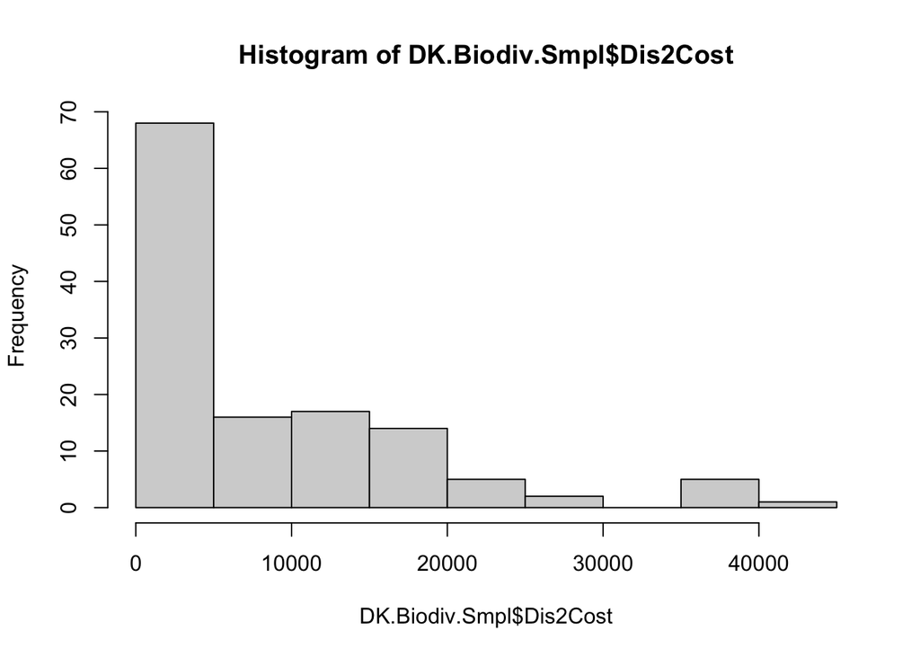

```r
# Histograms for Distance to coast

## Sturges" intervals
hist(x = DK.Biodiv.Smpl$Dis2Cost, # Vector to summarize
     breaks = "Sturges" # how the brakes in the histogram are defined
     )
```

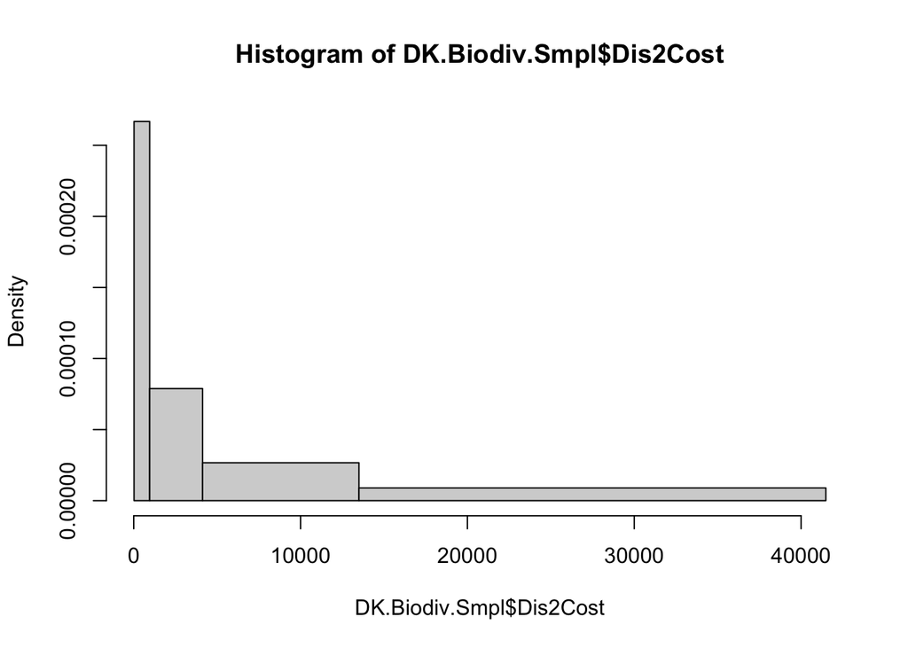

```r
## quantile intervals
hist(x = DK.Biodiv.Smpl$Dis2Cost, # Vector to summarize
     breaks = quantile(na.omit(DK.Biodiv.Smpl$Dis2Cost)) # how the brakes in the histogram are defined
     )
```

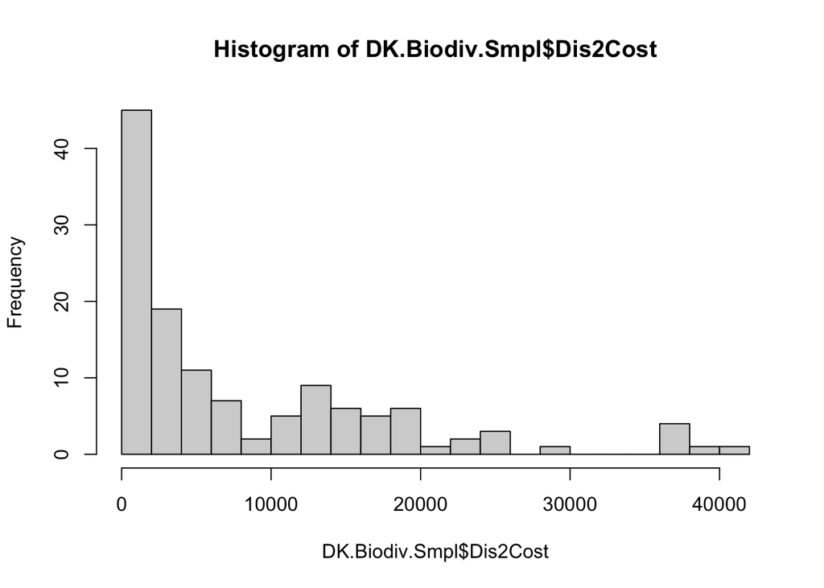

```r
## 15 intervals
hist(x = DK.Biodiv.Smpl$Dis2Cost, # Vector to summarize
     breaks = 15 # how the brakes in the histogram are defined
     )
```

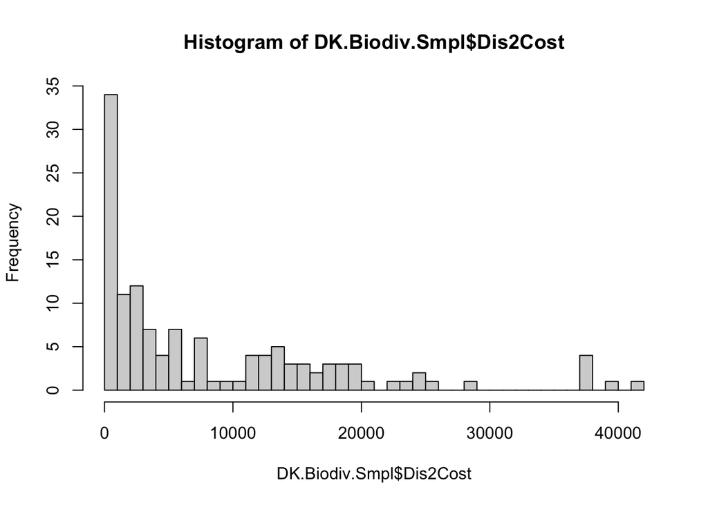

```r
## 30 intervals
hist(x = DK.Biodiv.Smpl$Dis2Cost, # Vector to summarize
     breaks = 30 # how the brakes in the histogram are defined
     )
```

**Question:** Based on these histograms, does *Distance to coast* appear to be normally distributed, left-skewed, or right-skewed?

**Your task:**

- Based on the data stored in the `DK.Biodiv.Smpl` object, you will write code to make a density plot for *Nature Density* [`NatDensBasMp`], *Distance to coast* [`Dis2Cost`], *Human Impact Index* [`HII`], *Slope* [`Slope30mAgg`], and *Precipitation Seasonality* [`PrecSea`].
  - The function `density()` **MUST* be used to build the kernel density estimates.
  - You **MUST** use a `for()` loop** for making this series of plots.
  - All density plots need to be placed in the same plotting space divided into two (2) rows and three (3) columns.

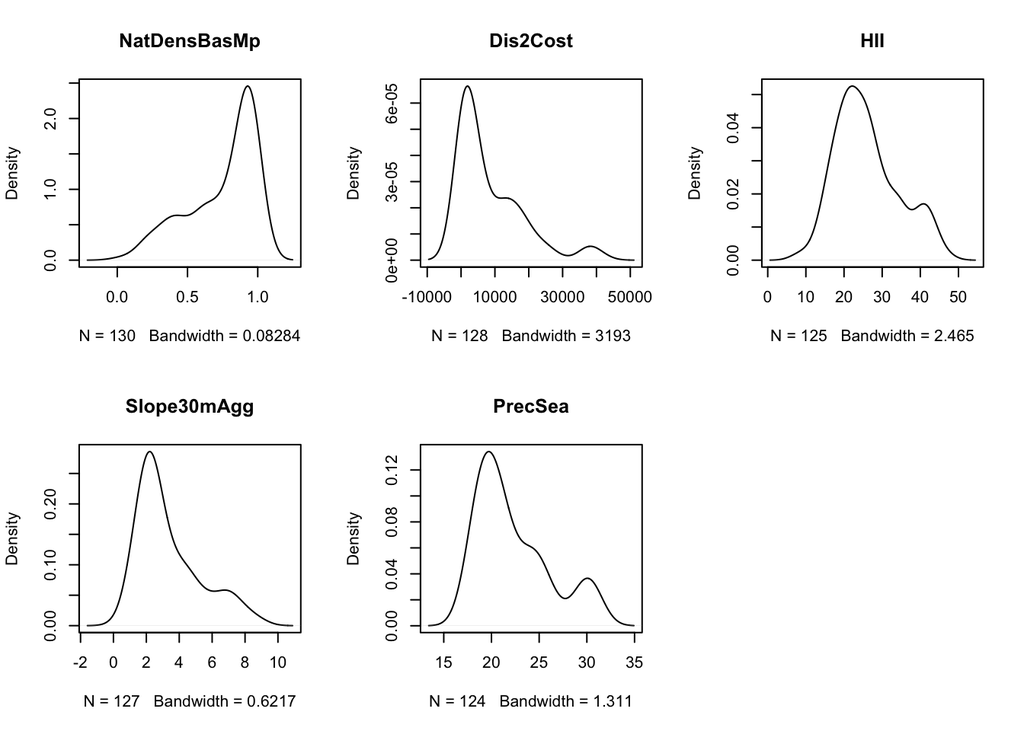

```r
# plot a density plots for env predictors in a 2x3 plotting space

## set the ploting space to a 2x3 space
par(mfrow = c(2,3))

# the loop
for (i in names(DK.Biodiv.Smpl)[4:8]){ # Loop over all the selected variables
  DensityTmp <- density(x = na.omit(DK.Biodiv.Smpl[,i]) #data from which the estimate is to be computed
                        )
  plot(DensityTmp, # Plot the kernel density estimates
       main = i # Add the name of the variable as a main title
  )
}
```

**Question:** Based on these density plots, which variables **LOOK** normally distributed, left-skewed, or right-skewed?

**Your task:**

- Based on the data stored in the `DK.Biodiv.Smpl` object, you will test the normality of *Nature Density* [`NatDensBasMp`], *Distance to coast* [`Dis2Cost`], *Human Impact Index* [`HII`], *Slope* [`Slope30mAgg`], and *Precipitation Seasonality* [`PrecSea`].
  - You will use **Q_Q plots** test for normality using the `qqnorm()` and `qqline()` functions.
  - You **MUST** use a `for()` loop to make all the tests.
  - All **Q_Q plots** need to be placed in the same plotting space divided into two (2) rows and three (3)

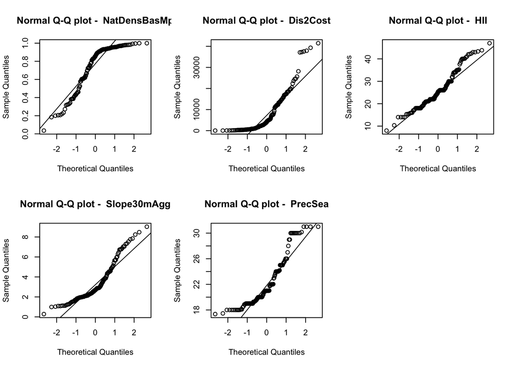

```r
## set the ploting space to a 2x3 space
par(mfrow = c(2,3))

# the loop
for (i in names(DK.Biodiv.Smpl)[4:8]){ # Loop over all the selected variables
  qqnorm(na.omit(DK.Biodiv.Smpl[,i]), # Plot the QQ-plot
         main = paste("Normal Q-Q plot - ", i) # add a title with the variable name
         )
  qqline(na.omit(DK.Biodiv.Smpl[,i])) # add the trend line
}
```

**Question:** Based on these QQ-plots, which variables **LOOK** normally distributed?

**Your task:**

- Based on the data stored in the `DK.Biodiv.Smpl` object, you will test the normality of *Nature Density* [`NatDensBasMp`], *Distance to coast* [`Dis2Cost`], *Human Impact Index* [`HII`], *Slope* [`Slope30mAgg`], and *Precipitation Seasonality* [`PrecSea`].
  - You will use the `shapiro.test()` function to test for normality
  - You **MUST** use a `sapply()` function to make all the tests.
  - For each test you will summarize the Variable evaluated (`VarUsed`), the statistic value (`W`) with three (3) decimal points, and the p-value (`p.value`) with three (3) decimal points into one table.

```r
# test the normality for evaluated variables using a shapiro.test()
ShapTest <- sapply(X = names(DK.Biodiv.Smpl)[4:8], # Vector defining the loop
                    FUN = function(x){ # Function to be applied over
                      # Shapiro test
                      ShpTestTmp <- shapiro.test(na.omit(DK.Biodiv.Smpl[,x]) # vector of data values
                                                 )
                      # Summary of Shapiro test
                      ShpTestOut <- data.frame(VarUsed = x, # Variable evaluated
                                               W = round(ShpTestTmp$statistic,3), # statistic value
                                               p.value = round(ShpTestTmp$p.value,3) # p-value
                                               )
                      return(ShpTestOut)
                    }
                    )
ShapTest
```

```
##         NatDensBasMp   Dis2Cost   HII   Slope30mAgg   PrecSea
## VarUsed "NatDensBasMp" "Dis2Cost" "HII" "Slope30mAgg" "PrecSea"
## W       0.846          0.797      0.957 0.891         0.877
## p.value 0              0          0.001 0             0
```

**Question:** Based on these density plots, which variables **ARE** normally distributed?

NONE of the evaluated variables is normaly distributed according to the Shapiro-test, as all these have p-values below 0.05; indicating a significant difference from a normal distribution.

## *5. Transformations*

**Your task:**

- Based on the data stored in the `DK.Biodiv.Smpl` object, you will try different transformations for *Nature Density* [`NatDensBasMp`] and test if these linearize the Q-Q plots.
  1. A `log10()` transformation.
  2. A squared-root (`sqrt()`) transformation.
  3. An Arc-sin (`asin()`) transformation.
  4. a Logit (`log(p/1-p)`) transformation.

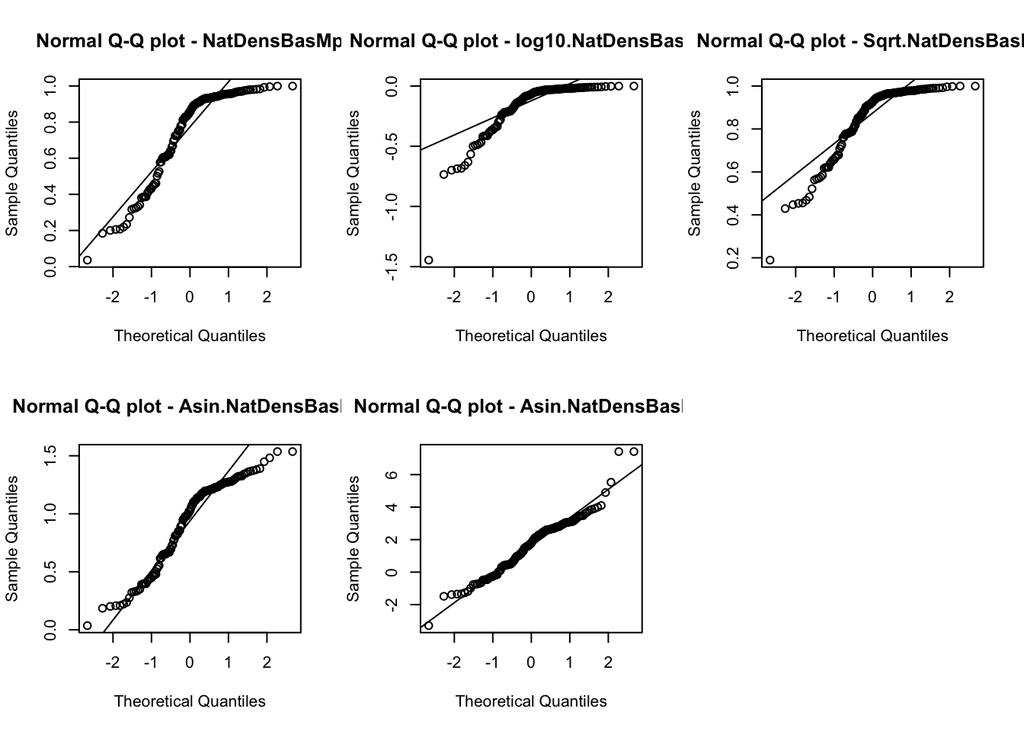

```r
# Try different transformations for  *Nature Density
## set the ploting space to a 2x3 space
par(mfrow = c(2,3))

## NO transformation.
## plot the qq-pot and qqline
qqnorm(na.omit(DK.Biodiv.Smpl$NatDensBasMp), # Plot the QQ-plot
         main = "Normal Q-Q plot - NatDensBasMp" # add a title with the variable name
         )
qqline(na.omit(DK.Biodiv.Smpl$NatDensBasMp)) # add the trend line

## A `log10()` transformation.
log10.NatDensBasMp <- log10(DK.Biodiv.Smpl$NatDensBasMp)
## plot the qq-pot and qqline
qqnorm(na.omit(log10.NatDensBasMp), # Plot the QQ-plot
         main = "Normal Q-Q plot - log10.NatDensBasMp" # add a title with the variable name
         )
qqline(na.omit(log10.NatDensBasMp)) # add the trend line

## A squared-root (`sqrt()`) transformation.
Sqrt.NatDensBasMp <- sqrt(DK.Biodiv.Smpl$NatDensBasMp)
## plot the qq-pot and qqline
qqnorm(na.omit(Sqrt.NatDensBasMp), # Plot the QQ-plot
         main = "Normal Q-Q plot - Sqrt.NatDensBasMp" # add a title with the variable name
         )
qqline(na.omit(Sqrt.NatDensBasMp)) # add the trend line

## An Arc-sin (`asin()`) transformation.
Asin.NatDensBasMp <- asin(DK.Biodiv.Smpl$NatDensBasMp)
## plot the qq-pot and qqline
qqnorm(na.omit(Asin.NatDensBasMp), # Plot the QQ-plot
         main = "Normal Q-Q plot - Asin.NatDensBasMp" # add a title with the variable name
         )
qqline(na.omit(Asin.NatDensBasMp)) # add the trend line

## A Logit (`log(p/1-p)`) transformation.
Logit.NatDensBasMp <- log(DK.Biodiv.Smpl$NatDensBasMp/(1-DK.Biodiv.Smpl$NatDensBasMp))
## plot the qq-pot and qqline
qqnorm(na.omit(Logit.NatDensBasMp), # Plot the QQ-plot
         main = "Normal Q-Q plot - Asin.NatDensBasMp" # add a title with the variable name
         )
qqline(na.omit(Logit.NatDensBasMp)) # add the trend line

DK.Biodiv.Smpl$Logit.NatDensBasMp <- Logit.NatDensBasMp
```

**Question:** Based on these Q-Q plots, which transformation makes Nature Density more normally distributed?

A Logit transformation makes Nature Density more normally distributed, as it is closer to the 1:1 line

**Your task:**

- Based on the data stored in the `DK.Biodiv.Smpl` object, you will try different transformations for *Distance to coast* [`Dis2Cost`] and test if these linearise the Q-Q plots.
  1. A `log10()` transformation.
  2. A squared-root (`sqrt()`) transformation.

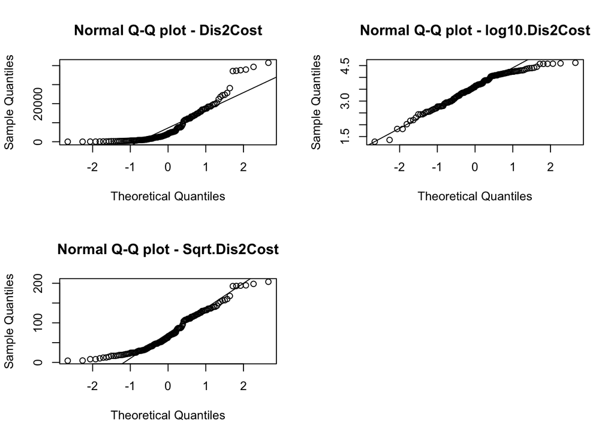

```r
# Try different transformations for  Distance to coast
## set the ploting space to a 2x3 space
par(mfrow = c(2,2))

## NO transformation.
## plot the qq-pot and qqline
qqnorm(na.omit(DK.Biodiv.Smpl$Dis2Cost), # Plot the QQ-plot
         main = "Normal Q-Q plot - Dis2Cost" # add a title with the variable name
         )
qqline(na.omit(DK.Biodiv.Smpl$Dis2Cost)) # add the trend line

## A `log10()` transformation.
log10.Dis2Cost <- log10(DK.Biodiv.Smpl$Dis2Cost)
## plot the qq-pot and qqline
qqnorm(na.omit(log10.Dis2Cost), # Plot the QQ-plot
         main = "Normal Q-Q plot - log10.Dis2Cost" # add a title with the variable name
         )
qqline(na.omit(log10.Dis2Cost)) # add the trend line

DK.Biodiv.Smpl$log10.Dis2Cost <- log10.Dis2Cost
## A squared-root (`sqrt()`) transformation.
Sqrt.Dis2Cost <- sqrt(DK.Biodiv.Smpl$Dis2Cost)
## plot the qq-pot and qqline
qqnorm(na.omit(Sqrt.Dis2Cost), # Plot the QQ-plot
         main = "Normal Q-Q plot - Sqrt.Dis2Cost" # add a title with the variable name
         )
qqline(na.omit(Sqrt.Dis2Cost)) # add the trend line
```

**Question:** Based on these Q-Q plots, which transformation makes Distance to coast more normally distributed?

A Log transformation makes Distance to coast more normally distributed, as it is closer to the 1:1 line

## *6. Modelling*

**Your task:**

- Based on the data stored in the `DK.Biodiv.Smpl` object, you will evaluate the correlations between *Nature Density* [`NatDensBasMp`], *Distance to coast* [`Dis2Cost`], *Human Impact Index* [`HII`], *Slope* [`Slope30mAgg`], and *Precipitation Seasonality* [`PrecSea`]. **Remember to use the appropriate correlation coefficient**.

```r
# Evaluate the correlations between predictors
cor(x= na.omit(DK.Biodiv.Smpl[,names(DK.Biodiv.Smpl)[4:8]]), # matrix with values
    method = "spearman" # correlation coefficient to use
    )
```

```
##              NatDensBasMp   Dis2Cost         HII Slope30mAgg     PrecSea
## NatDensBasMp   1.00000000 -0.1707608 -0.36673952  0.01600833  0.27263138
## Dis2Cost      -0.17076080  1.0000000  0.21814983  0.12303977  0.12774358
## HII           -0.36673952  0.2181498  1.00000000  0.01393582 -0.09149425
## Slope30mAgg    0.01600833  0.1230398  0.01393582  1.00000000 -0.46777395
## PrecSea        0.27263138  0.1277436 -0.09149425 -0.46777395  1.00000000
```

**Your task:**

- Based on the data stored in the `DK.Biodiv.Smpl` object, you will visualize a series of scatter-plots showing the asociations between *Nature Density* [`NatDensBasMp`], *Distance to coast* [`Dis2Cost`], *Human Impact Index* [`HII`], *Slope* [`Slope30mAgg`], and *Precipitation Seasonality* [`PrecSea`]. .
  - For this you **MUST** use the function `pairs()` and try to add a smoothed line in each panel

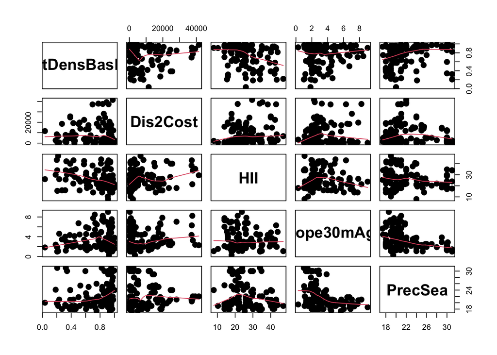

```r
# visualize the correlations between
pairs(DK.Biodiv.Smpl[,names(DK.Biodiv.Smpl)[4:8]], # What to plot
      panel = panel.smooth, # add a smoothed line in each panel
      cex = 1.5, pch = 19, bg = "black", # Set the point to filled, black and large points
      cex.labels = 2, font.labels = 2 # Set the size and boldface for the labels
      )
```

**Question:** DO you see strong associations between predictors? is yes/no, What does that indicate?

There are only weak to moderate associations between predictors (most between -0.7 and 0.7).

**Your task:**

- Based on the data stored in the `DK.Biodiv.Smpl` object, you will visualize the scatter plot showing the association between *Richness of all sampled species* [`S.AllGrp`] as the response variable (y-axis) and *Nature Density* [`NatDensBasMp`], *Distance to coast* [`Dis2Cost`], *Human Impact Index* [`HII`], *Slope* [`Slope30mAgg`], and *Precipitation Seasonality* [`PrecSea`] as predictors (x-axis).
  - All **scatter-plots** need to be placed in the same plotting space divided into two (2) rows and three (3)
  - Need to add the correlation coefficient with three (3) decimal points as a text insert on the top-right of each panel.
  - You most use a `for()` loop to make this plot.

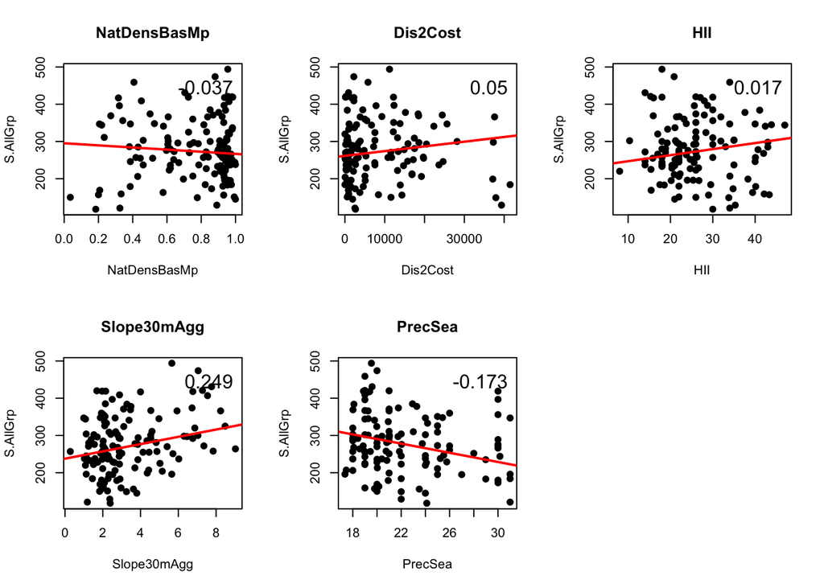

```r
# Visualize the scatter plot showing the association between *Richness (y-axis) and all predictors (x-axis)
## set the ploting space to a 2x3 space
par(mfrow = c(2,3))

## Loop
for (i in names(DK.Biodiv.Smpl)[4:8]){ # Loop over all the selected variables
## Plot the scatter plot
  plot(DK.Biodiv.Smpl[,c(i,"S.AllGrp")], # data to plot
       pch = 19, # make filled circles
       main = i # add the variable name as a Title
       )
  ## Define the trend line regression
  LineTrnd <- line(DK.Biodiv.Smpl[,c(i,"S.AllGrp")]) # data to define the liner relation
  ## plot the trend line
  abline(coef(LineTrnd), # Coefficnets of the trend line
         lwd = 2, col ="red" # Parameter for the line (thick line and red)
         )
  ## Estimate the correlation
  CorTest <- cor(na.omit(DK.Biodiv.Smpl[,c(i,"S.AllGrp")]),method="spearman")
  ## Add the correlation as a text insert
  legend("topright", # Put the legend in the top right corner
         legend = round(CorTest[2,1],3), # add the correlation coefficient
        bty = "n",
        cex=1.5)
}
```

**Question:** Based on this figure, which is the best predictor of species richness in the dataset?

Figure points to *Slope* and *Precipitation seasonality as the best predictors for species richness as these have the strongest correlations.

## *7. Final Thoughts*

Exploratory data analysis is when a person used different approaches to learn about general patterns or tendencies in the data and find specific occurrences that deviate from the general patterns. Much like a detective explores a crime scene, collects evidence and draws conclusions, a statistician explores data using graphical displays and suitable summaries to draw conclusions about the main message of the data.

Here you have taken the first steps in this direction by describing the variation in the data, assessing the differences between groups, and establishing the relations between variables.